# Задачи по Эконометрике: Категориальные переменные

Н.В. Артамонов (МГИМО МИД России)

# 1 Категориальные признаки

## 1.1 diamond equation #1

### 1.1.1 Описательные статистики

Для набора данных `Diamond` вычислите описательные статистики для количественных и категрриальных переменных

```
     carat        colour clarity   certification     price
 Min.   :0.1800   D:16   IF  :44   GIA:151       Min.   :  638
 1st Qu.:0.3500   E:44   VS1 :81   HRD: 79       1st Qu.: 1625
 Median :0.6200   F:82   VS2 :53   IGI: 78       Median : 4215
 Mean   :0.6309   G:65   VVS1:52                 Mean   : 5019
 3rd Qu.:0.8500   H:61   VVS2:78                 3rd Qu.: 7446
 Max.   :1.1000   I:40                           Max.   :16008
```

### 1.1.2 Регрессии

Для набора данных `Diamond` рассмотрим несколько линейных регрессий.

1. **log(price) ~ carat + I(carat^2) + colour**
2. **log(price) ~ carat + I(carat^2) + certification**
3. **log(price) ~ carat + I(carat^2) + colour + certification**

Оцените регрессии и дайте интерпретацию коэффициентам для категрриальных переменных. **Ответ округлите до 2 десятичных знаков**

Результаты оценивания

```
(Intercept)       carat  I(carat^2)     colourE     colourF     colourG
       5.98        5.40       -1.98       -0.07       -0.14       -0.21
    colourH     colourI
      -0.30       -0.40
```

```
     (Intercept)            carat       I(carat^2) certificationHRD
            5.69             5.65            -2.19             0.03
certificationIGI
            0.07
```

```
     (Intercept)            carat       I(carat^2)          colourE
            5.87             5.67            -2.15            -0.08
         colourF          colourG          colourH          colourI
           -0.15            -0.23            -0.31            -0.41
certificationHRD certificationIGI
            0.04             0.09
```

## 1.2 diamond equation #2

### 1.2.1 Описательные статистики

Для набора данных `diamonds` вычислите описательные статистики для количественных и категрриальных переменных

```
     carat               cut        color        clarity          depth
 Min.   :0.2000   Fair     : 1610   D: 6775   SI1    :13065   Min.   :43.00
 1st Qu.:0.4000   Good     : 4906   E: 9797   VS2    :12258   1st Qu.:61.00
 Median :0.7000   Very Good:12082   F: 9542   SI2    : 9194   Median :61.80
 Mean   :0.7979   Premium  :13791   G:11292   VS1    : 8171   Mean   :61.75
 3rd Qu.:1.0400   Ideal    :21551   H: 8304   VVS2   : 5066   3rd Qu.:62.50
 Max.   :5.0100                     I: 5422   VVS1   : 3655   Max.   :79.00
                                    J: 2808   (Other): 2531
     table           price             x                y
 Min.   :43.00   Min.   :  326   Min.   : 0.000   Min.   : 0.000
 1st Qu.:56.00   1st Qu.:  950   1st Qu.: 4.710   1st Qu.: 4.720
 Median :57.00   Median : 2401   Median : 5.700   Median : 5.710
 Mean   :57.46   Mean   : 3933   Mean   : 5.731   Mean   : 5.735
 3rd Qu.:59.00   3rd Qu.: 5324   3rd Qu.: 6.540   3rd Qu.: 6.540
 Max.   :95.00   Max.   :18823   Max.   :10.740   Max.   :58.900

       z
 Min.   : 0.000
 1st Qu.: 2.910
 Median : 3.530
 Mean   : 3.539
 3rd Qu.: 4.040
 Max.   :31.800
```

### 1.2.2 Регрессии

Для набора данных `diamonds` рассмотрим несколько линейных регрессий.

1. **log(price) ~ carat + I(carat^2) + cut + x + y + z**
2. **log(price) ~ carat + I(carat^2) + color + x + y + z**
3. **log(price) ~ carat + I(carat^2) + color + cut + x + y + z**

Оцените регрессии и дайте интерпретацию коэффициентам для категрриальных переменных. **Ответ округлите до 2 десятичных знаков**

Результаты оценивания

```
 (Intercept)        carat   I(carat^2)      cutGood cutVery Good   cutPremium
        3.80         2.37        -0.64         0.12         0.17         0.16
    cutIdeal            x            y            z
        0.24         0.38         0.02         0.06
```

```
(Intercept)       carat  I(carat^2)      colorE      colorF      colorG
       4.08        2.35       -0.61       -0.03       -0.04       -0.07
     colorH      colorI      colorJ           x           y           z
      -0.21       -0.30       -0.43        0.38        0.03        0.05
```

```
 (Intercept)        carat   I(carat^2)       colorE       colorF       colorG
        3.99         2.54        -0.65        -0.03        -0.04        -0.07
      colorH       colorI       colorJ      cutGood cutVery Good   cutPremium
       -0.21        -0.31        -0.43         0.12         0.18         0.16
    cutIdeal            x            y            z
        0.25         0.34         0.01         0.06
```

# 2 Структурные сдвиги

## 2.1 Графики

Для набора данных `sleep75` рассмотрим линейную регрессию **sleep на totwrk** и подгоним отдельно для south=0, отдельно для south=1 и по полному датасету

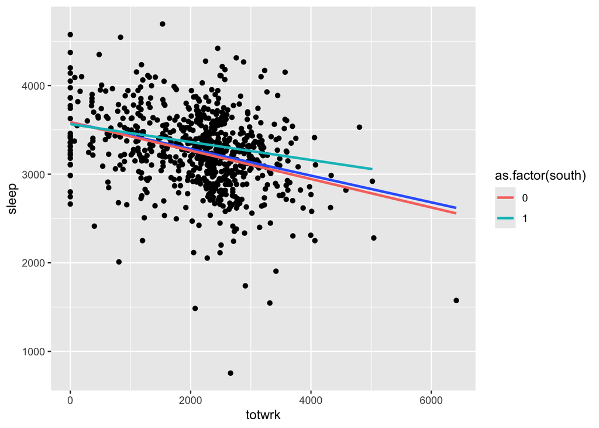

Для набора данных `sleep75` рассмотрим линейную регрессию **sleep на age, age^2** и подгоним отдельно для south=0, отдельно для south=1 и по полному датасету

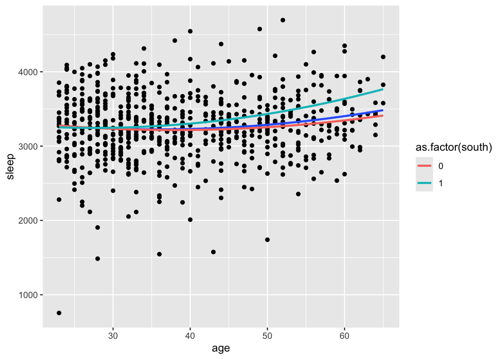

## 2.2 sleep equation #1

Для набора данных `sleep75` рассмотрим линейную регрессию **sleep на totwrk, age, smsa**: исходную и со структурными сдвигами относительно гендерной переменной.

Результаты оценивания

```
================================================
                        Зависимая переменная
                    ----------------------------
                               sleep
                         (1)            (2)
------------------------------------------------
totwrk                -0.150***      -0.143***
                       (0.017)        (0.026)

age                    2.997**         1.704
                       (1.393)        (2.085)

smsa                  -73.501**       -56.649
                       (32.219)      (48.902)

male                                  135.200
                                     (143.832)

totwrk:male                           -0.045
                                      (0.036)

age:male                               1.500
                                      (2.825)

smsa:male                             -34.735
                                     (64.938)

Constant             3498.670***    3486.973***
                       (69.133)      (92.418)

------------------------------------------------
Observations             706            706
R2                      0.115          0.126
Adjusted R2             0.112          0.117
Residual Std. Error    418.877        417.530
F Statistic           30.527***      14.387***
================================================
Note:                *p<0.1; **p<0.05; ***p<0.01
```

Для второй регрессии дайте интерпретацию коэффициентов.

## 2.3 sleep equation #2

Для набора данных `sleep75` рассмотрим линейную регрессию **sleep на totwrk, age, smsa**: исходную и со структурными сдвигами относительно географической переменной.

Результаты оценивания

```
================================================
                        Зависимая переменная
                    ----------------------------
                               sleep
                         (1)            (2)
------------------------------------------------
totwrk                -0.150***      -0.161***
                       (0.017)        (0.018)

age                    2.997**         1.485
                       (1.393)        (1.545)

smsa                  -73.501**      -61.554*
                       (32.219)      (34.856)

south                               -407.206**
                                     (189.627)

totwrk:south                           0.078
                                      (0.050)

age:south                             8.267**
                                      (3.495)

smsa:south                            49.429
                                     (107.111)

Constant             3498.670***    3557.513***
                       (69.133)      (75.504)

------------------------------------------------
Observations             706            706
R2                      0.115          0.131
Adjusted R2             0.112          0.122
Residual Std. Error    418.877        416.341
F Statistic           30.527***      15.039***
================================================
Note:                *p<0.1; **p<0.05; ***p<0.01
```

Для второй регрессии дайте интерпретацию коэффициентов.

## 2.4 wage equation #1

Для набора данных `wage2` рассмотрим линейную регрессию **log(wage) на age, IQ, urban, married**: исходную и со структурными сдвигами относительно географической переменной.

Результаты оценивания

```
================================================
                        Зависимая переменная
                    ----------------------------
                             log(wage)
                         (1)            (2)
------------------------------------------------
age                    0.022***      0.024***
                       (0.004)        (0.005)

IQ                     0.009***      0.008***
                       (0.001)        (0.001)

urban                  0.186***      0.217***
                       (0.028)        (0.035)

married                0.198***      0.201***
                       (0.041)        (0.049)

south                                 -0.011
                                      (0.348)

age:south                             -0.007
                                      (0.009)

IQ:south                               0.002
                                      (0.002)

urban:south                          -0.114**
                                      (0.057)

married:south                         -0.003
                                      (0.087)

Constant               4.849***      4.914***
                       (0.163)        (0.204)

------------------------------------------------
Observations             935            935
R2                      0.188          0.205
Adjusted R2             0.184          0.197
Residual Std. Error     0.380          0.377
F Statistic           53.799***      26.481***
================================================
Note:                *p<0.1; **p<0.05; ***p<0.01
```

Для второй регрессии дайте интерпретацию коэффициентов.

## 2.5 wage equation #2

Результаты оценивания

```
================================================
                        Зависимая переменная
                    ----------------------------
                             log(wage)
                         (1)            (2)
------------------------------------------------
age                    0.023***      0.024***
                       (0.004)        (0.007)

IQ                     0.008***      0.008***
                       (0.001)        (0.002)

south                 -0.113***       -0.014
                       (0.028)        (0.052)

urban                                  0.237
                                      (0.368)

age:urban                             -0.001
                                      (0.009)

IQ:urban                             -0.00001
                                      (0.002)

south:urban                           -0.117*
                                      (0.061)

Constant               5.214***      4.999***
                       (0.168)        (0.312)

------------------------------------------------
Observations             935            935
R2                      0.146          0.182
Adjusted R2             0.143          0.176
Residual Std. Error     0.390          0.382
F Statistic           52.872***      29.417***
================================================
Note:                *p<0.1; **p<0.05; ***p<0.01
```

Для второй регрессии дайте интерпретацию коэффициентов.